# Homework H

`forcats`: working with categorical data

Author

```r
#LOAD PACKAGES
library(tidyverse)
library(forcats)
library(kableExtra)
library(ggthemes)

#LOAD DATASET
# This diamonds dataset is built into the tidyverse package
data("gss_cat")
```

Today’s dataset, `gss_cat`, is a sample of data from the General Social Survey, a long-running US survey conducted by the independent research organization NORC at the University of Chicago. The survey has thousands of questions, but `gss_cat` only contains the 9 variables.

Begin by reading more about each variable in the dataset by typing `?gss_cat` into the console.

# 1.

For each categorical/factor variable in `gss_cat` identify whether the order of the levels is ordinal or nominal.

marital - race - rincome - partyid - relig - denom -

# 2.

What are the levels of the variable `partyid`? Create a table which displays how many people are in each category of `partyid`.

```r
gss_cat |>
  pull(partyid) |>
  levels()
```

```
 [1] "No answer"          "Don't know"         "Other party"
 [4] "Strong republican"  "Not str republican" "Ind,near rep"
 [7] "Independent"        "Ind,near dem"       "Not str democrat"
[10] "Strong democrat"
```

# 3.

Construct a barplot which displays `partyid` on the x-axis and the the height of the bars represents the count of how many people fall in each category. What makes the default bar chart hard to understand?

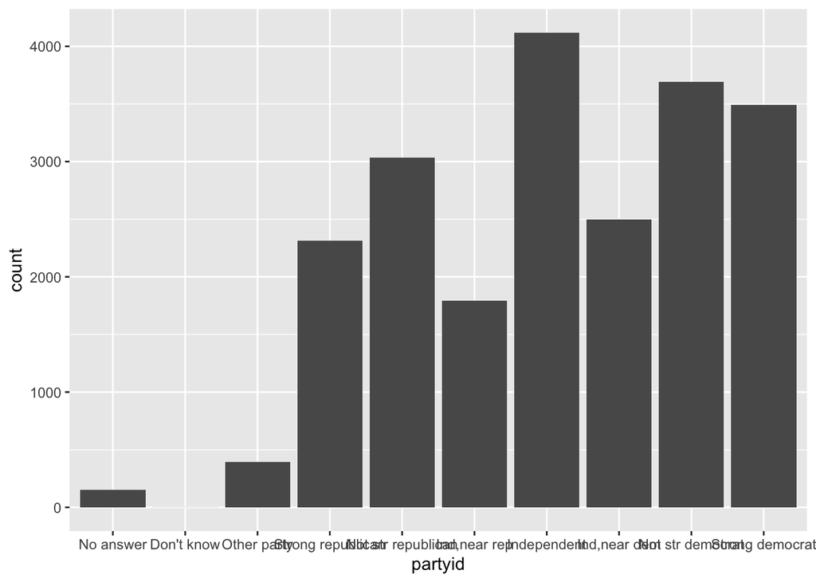

```r
gss_cat |>
  group_by(partyid) |>
  summarize(count=n()) |>
ggplot() +
  geom_col(aes(x=partyid, y=count))
```

# 4.

Regroup `partyid` variable to only contain four groups: “rep”, “ind”, “dem”, and “other”. Recreate the barchart above with your improved groupings.

# 5.

What are the levels of the `relig` variable? Create a table which counts how many people belong to each religion. Be sure to print out your table in a pretty way using the `kableExtra` package.

```r
gss_cat |>
  pull(relig) |>
  levels()
```

```
 [1] "No answer"               "Don't know"
 [3] "Inter-nondenominational" "Native american"
 [5] "Christian"               "Orthodox-christian"
 [7] "Moslem/islam"            "Other eastern"
 [9] "Hinduism"                "Buddhism"
[11] "Other"                   "None"
[13] "Jewish"                  "Catholic"
[15] "Protestant"              "Not applicable"
```

# 6.

Create a new variable in the dataset called `top_relig` which only contains the 5 most popular religions and all other categories are grouped into an “other category”. Create table which counts the number of people in each `top_relig` category. Be sure to print out your table is a pretty way using the `kableExtra` package.

```r
gss_cat |>
  mutate(top_relig = relig |> fct_lump_n(5)) |>
  count(top_relig) |>
  kbl() |>
  kable_styling()
```

| top_relig | n |
| --- | --- |
| Christian | 689 |
| None | 3523 |
| Jewish | 388 |
| Catholic | 5124 |
| Protestant | 10846 |
| Other | 913 |

# 7.

Explore the relationship between marital status and the number of TV hours watched. Your results should include an appropriate plot that is well-labelled. Pay attention to the ordering of any categorical variables in your plot to ensure they are ordered in an appropriate way.

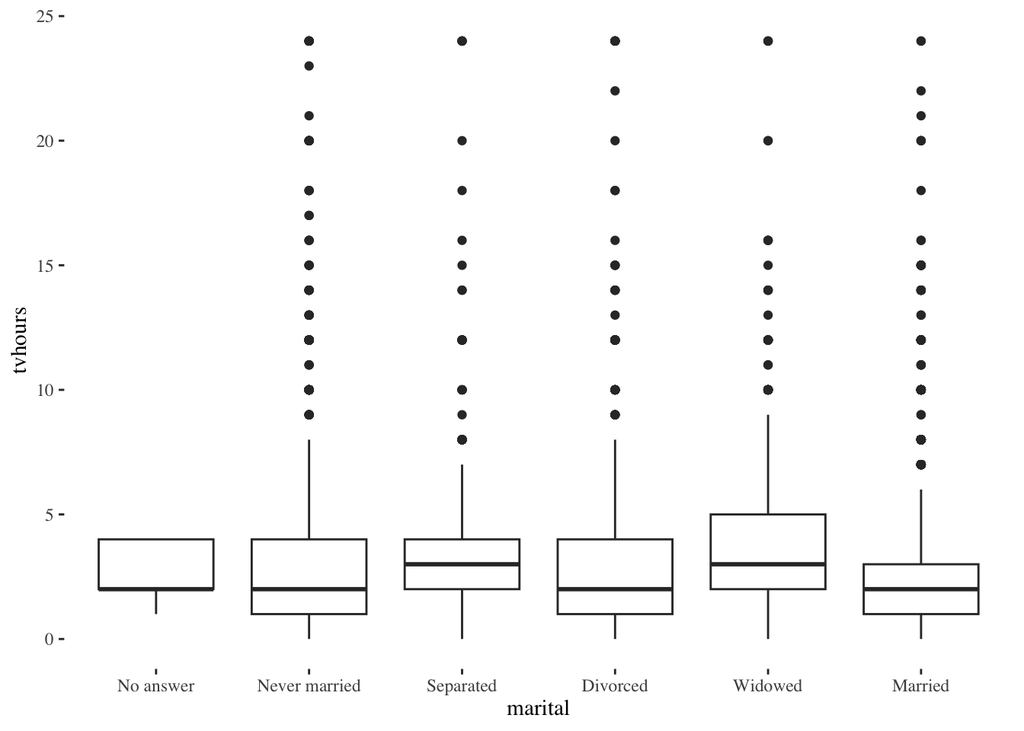

```r
gss_cat |>
  ggplot() +
  geom_boxplot(aes(x=marital, y=tvhours)) +
  theme_tufte()
```

# 8.

Explore the relationship between one of the categorical variables in this dataset over time. Your results should include an appropriate plot that is well-labelled. Pay attention to the ordering of any categorical variables in your plot to ensure they are ordered in an appropriate way.

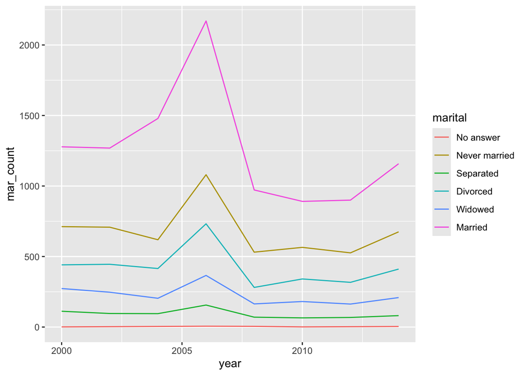

```r
gss_cat |>
  group_by(year, marital) |>
  summarize(mar_count=n()) |>
  ggplot() +
  geom_line(aes(x=year, y=mar_count, color=marital))
```